# Tugas 3

Rafi AKbar Wibawa

2023-09-17

```r
data <- import("https://raw.githubusercontent.com/rafi2411/MPDW-STA1341/main/Pertemuan%203/Data/Data%20Mentah%202.csv")
#SPLIT DATA
n <- 75/100*nrow(data)
train<-data[1:n,]
test<-data[(n+1):nrow(data),]
```

```r
#data time series
train.ts<-ts(train)
test.ts<-ts(test)
data.ts<-ts(data)
```

### Pemodelan Koyck

```r
#MODEL KOYCK
model.koyck <- koyckDlm(x = train$V3, y = train$V2)
summary(model.koyck)
```

```
##
## Call:
## "Y ~ (Intercept) + Y.1 + X.t"
##
## Residuals:
##     Min      1Q  Median      3Q     Max
## -6462.5  -183.6   146.8   194.5  1949.1
##
## Coefficients:
##               Estimate Std. Error t value Pr(>|t|)
## (Intercept) -241.56605  296.84489  -0.814    0.416
## Y.1           -0.04143    0.04371  -0.948    0.344
## X.t            1.09406    0.11502   9.512   <2e-16 ***
## ---
## Signif. codes:  0 '***' 0.001 '**' 0.01 '*' 0.05 '.' 0.1 ' ' 1
##
## Residual standard error: 509.2 on 344 degrees of freedom
## Multiple R-Squared: 0.9822,  Adjusted R-squared: 0.9821
## Wald test:  1354 on 2 and 344 DF,  p-value: < 2.2e-16
##
## Diagnostic tests:
## NULL
##
##                             alpha     beta         phi
## Geometric coefficients:  -231.956 1.094057 -0.04143044
```

```r
AIC(model.koyck)
```

```
## [1] 5315.257
```

```r
BIC(model.koyck)
```

```
## [1] 5330.654
```

### Peramalan dan Akurasi Koyck

```r
fore.koyck <- forecast(model = model.koyck, x=test$V3, h=nrow(test))
fore.koyck
```

```
## $forecasts
##   [1] 9567.5982 7485.4178 7667.4134 7564.1433 7653.8895 7571.5414 7670.6831
##   [8] 7570.8457 7660.4607 9783.3103 9715.8842 9698.1532 9719.4123 7571.4446
##  [15] 7660.4358 7656.7489 7431.2414 7440.5843 7440.1972 7440.2133 6681.8998
##  [22] 7143.4127 7124.2921 7125.0842 7114.8001 7115.2262 6961.3513 6967.7264
##  [29] 6502.4880 6538.8632 6520.2560 6538.1270 6222.8452 6201.7182 6236.7828
##  [36] 6850.7371 6903.9306 6823.0969 6860.6352 7337.7299 7461.5586 7459.8528
##  [43] 7401.7962 7414.4528 8412.2555 8370.9161 8328.1882 8364.1477 9849.8863
##  [50] 9788.3315 8344.6805 8353.2131 8363.1109 9340.5144 9300.0201 9301.6978
##  [57] 9301.6283 9814.4704 9375.5669 7715.4673 1918.4591 2158.6317 7553.0495
##  [64] 7271.4347 7330.9671 7803.7317 7801.2449 7773.9965 7795.6281 7203.2627
##  [71] 7104.7233 7108.8058  672.8460  897.0960  887.8052  888.1901  888.1742
##  [78] 8234.7680 9376.5966 9329.2901 9331.2500 6496.8827 6566.4468 6563.5647
##  [85] 9510.2533 9033.1492 9052.9158 9052.0969  596.4373 4490.6834  914.4833
##  [92]  840.5874 5915.9053  859.3675 1369.0440  976.2903 4837.0788  917.5685
##  [99] 1497.9195  967.1901 1106.1058 1551.6490 4397.4997  932.7034 1377.6300
## [106]  773.5340 4352.0593 1267.0768 1442.4121  802.9880 4412.1062  733.6295
## [113] 5073.6021 5050.2453 4886.0104 2947.5813
##
## $call
## forecast.koyckDlm(model = model.koyck, x = test$V3, h = nrow(test))
##
## attr(,"class")
## [1] "forecast.koyckDlm" "dLagM"
```

```r
mape.koyck <- MAPE(fore.koyck$forecasts, test$V2)
#akurasi data training
GoF(model.koyck)
```

```
##               n      MAE       MPE      MAPE     sMAPE      MASE    MSE
## model.koyck 347 291.1932 0.1559135 0.2052398 0.2190544 0.1311251 256995
##                     MRAE    GMRAE
## model.koyck 542661312696 603.2903
```

Pemodelan memberikan nilai akurasi yang kurang baik dengan nilai MAPE yang lebih dari 20%.

## Regression with Distributed Lag

### Pemodelan (Lag=2)

```r
model.dlm <- dlm(x = train$V3,y = train$V2 , q = 2)
summary(model.dlm)
```

```
##
## Call:
## lm(formula = model.formula, data = design)
##
## Residuals:
##     Min      1Q  Median      3Q     Max
## -5977.0    -1.2    13.1    58.4  2306.8
##
## Coefficients:
##              Estimate Std. Error t value Pr(>|t|)
## (Intercept)  2.471761  33.514154   0.074    0.941
## x.t          0.991733   0.006278 157.979   <2e-16 ***
## x.1         -0.006518   0.005736  -1.136    0.257
## x.2          0.007864   0.006298   1.249    0.213
## ---
## Signif. codes:  0 '***' 0.001 '**' 0.01 '*' 0.05 '.' 0.1 ' ' 1
##
## Residual standard error: 368.9 on 342 degrees of freedom
## Multiple R-squared:  0.9907, Adjusted R-squared:  0.9906
## F-statistic: 1.216e+04 on 3 and 342 DF,  p-value: < 2.2e-16
##
## AIC and BIC values for the model:
##        AIC      BIC
## 1 5077.989 5097.221
```

```r
AIC(model.dlm)
```

```
## [1] 5077.989
```

```r
BIC(model.dlm)
```

```
## [1] 5097.221
```

Dari hasil diatas, didapat bahwa $P-value$ dari $x_{t}<0.05$. Hal ini menunjukkan bahwa $x_{t}$ berpengaruh signifikan terhadap $y$. Adapun model keseluruhan yang terbentuk adalah sebagai berikut

$$\hat{Y_t}=2.471+0.991X_t-0.006518X_{t-1}+0.007864X_{t-2}$$

### Peramalan dan Akurasi

Berikut merupakan hasil peramalan $y$ untuk 116 periode kedepan

```r
fore.dlm <- forecast(model = model.dlm, x=test$V3, h=nrow(test))
fore.dlm
```

```
## $forecasts
##   [1] 9256.7257 7378.6308 7477.7517 7375.5122 7454.2448 7381.7717 7469.6311
##   [8] 7381.7189 7460.4615 9386.9357 9393.4850 9390.0434 9408.9181 7462.3718
##  [15] 7475.3117 7459.8785 7255.3236 7256.6681 7255.0461 7255.0461 6567.6559
##  [22] 6962.0441 6954.0309 6957.1224 6947.8299 6947.8909 6808.3498 6809.2665
##  [29] 6386.6739 6404.9451 6386.0002 6401.7258 6116.3776 6087.3829 6116.3174
##  [36] 6673.7179 6741.5729 6674.2521 6706.2774 7139.3918 7266.9508 7272.6399
##  [43] 7220.9608 7230.6243 8135.1020 8129.2277 8096.1194 8127.3758 9474.9851
##  [50] 9466.3700 8166.1177 8128.2516 8127.4544 9013.3864 9007.6342 9014.6627
##  [57] 9014.6627 9479.5377 9097.8880 7582.7439 2272.5632 2295.4482 7152.1994
##  [64] 7067.3143 7149.8953 7579.9765 7592.9899 7571.5106 7590.3816 7053.9120
##  [71] 6946.0134 6942.4952 1107.7397 1107.6545 1061.6469 1061.3421 1061.3421
##  [78] 7720.8309 8988.0022 9032.1928 9042.5881 6473.3841 6446.8825 6426.7949
##  [85] 9097.4364 8758.0633 8781.3584 8778.8065 1113.9481 4376.7992 1199.4268
##  [92] 1043.9553 5618.5962 1193.7706 1531.2107 1157.7081 4647.0306 1213.5173
##  [99] 1642.4241 1153.6139 1265.6285 1670.3798 4264.9510 1217.2624 1530.9833
## [106]  974.2431 4201.0484 1513.6069 1599.7248 1005.2967 4256.9592 1032.1724
## [113] 4874.8707 4966.3730 4845.7892 3084.5964
##
## $call
## forecast.dlm(model = model.dlm, x = test$V3, h = nrow(test))
##
## attr(,"class")
## [1] "forecast.dlm" "dLagM"
```

```r
mape.dlm <- MAPE(fore.dlm$forecasts, test$V2)
#akurasi data training
GoF(model.dlm)
```

```
##             n      MAE          MPE       MAPE      sMAPE       MASE    MSE
## model.dlm 346 89.91741 -0.008791331 0.03494089 0.03167916 0.04046268 134523
##                   MRAE    GMRAE
## model.dlm 213322434370 76.13721
```

### *Lag* Optimum

```r
#penentuan lag optimum
finiteDLMauto(formula = V2 ~ V3,
              data = data.frame(train), q.min = 1, q.max = 10,
              model.type = "dlm", error.type = "AIC", trace = FALSE)
```

```
##    q - k    MASE      AIC      BIC    GMRAE    MBRAE R.Adj.Sq Ljung-Box
## 10    10 0.04462 4981.127 5030.827 139.2904 -0.21732  0.99036  0.207715
```

Berdasarkan output tersebut, lag optimum didapatkan ketika lag=10. Selanjutnya dilakukan pemodelan untuk lag=10

```r
model.dlm2 <- dlm(x = train$V3,y = train$V2 , q = 10)
summary(model.dlm2)
```

```
##
## Call:
## lm(formula = model.formula, data = design)
##
## Residuals:
##     Min      1Q  Median      3Q     Max
## -5894.5    -9.3    21.9    64.5  2323.9
##
## Coefficients:
##              Estimate Std. Error t value Pr(>|t|)
## (Intercept) -4.990113  41.232117  -0.121    0.904
## x.t          0.992487   0.006730 147.472   <2e-16 ***
## x.1         -0.008811   0.006963  -1.265    0.207
## x.2          0.007809   0.007289   1.071    0.285
## x.3          0.004409   0.007329   0.602    0.548
## x.4         -0.005253   0.007392  -0.711    0.478
## x.5          0.003541   0.007365   0.481    0.631
## x.6         -0.004308   0.007381  -0.584    0.560
## x.7          0.002176   0.007321   0.297    0.766
## x.8          0.010669   0.007279   1.466    0.144
## x.9         -0.006504   0.006965  -0.934    0.351
## x.10        -0.001313   0.006754  -0.194    0.846
## ---
## Signif. codes:  0 '***' 0.001 '**' 0.01 '*' 0.05 '.' 0.1 ' ' 1
##
## Residual standard error: 375.9 on 326 degrees of freedom
## Multiple R-squared:  0.9907, Adjusted R-squared:  0.9904
## F-statistic:  3148 on 11 and 326 DF,  p-value: < 2.2e-16
##
## AIC and BIC values for the model:
##        AIC      BIC
## 1 4981.127 5030.827
```

```r
AIC(model.dlm2)
```

```
## [1] 4981.127
```

```r
BIC(model.dlm2)
```

```
## [1] 5030.827
```

```r
#peramalan dan akurasi
fore.dlm2 <- forecast(model = model.dlm2, x=test$V3, h=nrow(test))
mape.dlm2<- MAPE(fore.dlm2$forecasts, test$V2)
#akurasi data training
GoF(model.dlm2)
```

```
##              n     MAE         MPE      MAPE      sMAPE       MASE      MSE
## model.dlm2 338 100.511 -0.01098391 0.0474346 0.04278361 0.04462106 136252.2
##                    MRAE    GMRAE
## model.dlm2 228736523772 139.2904
```

Model tersebut merupakan model yang sangat baik dengan nilai MAPE yang kurang dari 10%.

## Model Autoregressive

### Pemodelan

```r
model.ardl <- ardlDlm(x = train$V3, y = train$V2, p = 1 , q = 1)
summary(model.ardl)
```

```
##
## Time series regression with "ts" data:
## Start = 2, End = 348
##
## Call:
## dynlm(formula = as.formula(model.text), data = data, start = 1)
##
## Residuals:
##     Min      1Q  Median      3Q     Max
## -6024.2    -7.0     7.2    58.7  2311.3
##
## Coefficients:
##              Estimate Std. Error t value Pr(>|t|)
## (Intercept) 15.046393  32.298242   0.466    0.642
## X.t          0.994650   0.005614 177.165   <2e-16 ***
## X.1         -0.064158   0.053860  -1.191    0.234
## Y.1          0.059805   0.054142   1.105    0.270
## ---
## Signif. codes:  0 '***' 0.001 '**' 0.01 '*' 0.05 '.' 0.1 ' ' 1
##
## Residual standard error: 368.6 on 343 degrees of freedom
## Multiple R-squared:  0.9907, Adjusted R-squared:  0.9906
## F-statistic: 1.218e+04 on 3 and 343 DF,  p-value: < 2.2e-16
```

```r
AIC(model.ardl)
```

```
## [1] 5091.982
```

```r
BIC(model.ardl)
```

```
## [1] 5111.228
```

Hasil di atas menunjukkan bahwa selain peubah $x_{t}$, hasil uji t menunjukkan nilai-p pada peubah $\ge0.05$ Hal ini menunjukkan bahwa peubah $x_{t}$ berpengaruh signifikan terhadap $y_t$, sementara $x_{t-1}$ dan $y_{t-1}$ tidak berpengaruh signifikan terhadap $y_t$. Model keseluruhannya adalah sebagai berikut:

$$\hat{Y}=15.046+0.9946X_t-0.0641X_{t-1}+0,0598Y_{t-1}$$

### Peramalan dan Akurasi

```r
fore.ardl <- forecast(model = model.ardl, x=test$V3, h=nrow(test))
fore.ardl
```

```
## $forecasts
##   [1] 9243.368 7355.242 7450.855 7363.927 7442.044 7370.218 7457.566 7370.144
##   [9] 7448.242 9381.240 9390.795 9371.503 9390.212 7438.128 7447.295 7447.843
##  [17] 7242.719 7243.685 7243.743 7243.746 6554.335 6948.591 6946.947 6946.849
##  [25] 6937.523 6937.567 6797.692 6798.349 6375.662 6393.197 6377.697 6393.319
##  [33] 6107.289 6077.546 6108.855 6668.213 6737.061 6665.082 6696.471 7131.503
##  [41] 7259.998 7262.375 7209.471 7219.036 8126.624 8122.358 8081.700 8112.957
##  [49] 9464.919 9458.558 8143.379 8102.915 8112.822 9001.782 8997.604 8997.355
##  [57] 8997.340 9463.581 9081.682 7557.543 2231.996 2257.489 7172.335 7096.498
##  [65] 7138.887 7570.666 7584.166 7559.105 7577.850 7040.041 6930.664 6931.341
##  [73] 1080.354 1069.307 1071.132 1071.242 1071.248 7750.322 9033.736 9025.681
##  [81] 9025.199 6448.411 6417.001 6417.929 9096.825 8761.477 8762.241 8762.287
##  [89] 1074.891 4332.931 1215.371 1027.300 5640.459 1212.970 1505.290 1167.298
##  [97] 4664.078 1229.791 1624.862 1163.331 1271.746 1681.666 4283.771 1228.629
## [105] 1516.183  983.258 4216.354 1531.433 1586.284 1012.057 4271.892 1048.446
## [113] 4869.699 4994.893 4843.013 3075.131
##
## $call
## forecast.ardlDlm(model = model.ardl, x = test$V3, h = nrow(test))
##
## attr(,"class")
## [1] "forecast.ardlDlm" "dLagM"
```

Data di atas merupakan hasil peramalan untuk 116 periode ke depan menggunakan Model Autoregressive dengan $p=1$ dan $q=1$.

```r
mape.ardl <- MAPE(fore.ardl$forecasts, test$V2)
mape.ardl
```

```
## [1] 0.07413384
```

```r
#akurasi data training
GoF(model.ardl)
```

```
##              n      MAE          MPE     MAPE      sMAPE       MASE      MSE
## model.ardl 347 85.12707 -0.008584893 0.031412 0.02890038 0.03833295 134269.4
##                    MRAE    GMRAE
## model.ardl 201452308929 65.28787
```

### *Lag* Optimum

```r
#penentuan lag optimum
model.ardl.opt <- ardlBoundOrders(data = data.frame(data), ic = "AIC",
                                  formula = V2 ~ V3 )
min_p=c()
for(i in 1:6){
  min_p[i]=min(model.ardl.opt$Stat.table[[i]])
}
q_opt=which(min_p==min(min_p, na.rm = TRUE))
p_opt=which(model.ardl.opt$Stat.table[[q_opt]] ==
              min(model.ardl.opt$Stat.table[[q_opt]], na.rm = TRUE))
data.frame("q_optimum" = q_opt, "p_optimum" = p_opt,
           "AIC"=model.ardl.opt$min.Stat)
```

```
##   q_optimum p_optimum      AIC
## 1         1        15 6501.704
```

Dari tabel di atas, dapat terlihat bahwa nilai AIC terendah didapat ketika $p=15$ dan $q=1$, yaitu sebesar `6501.704`. Artinya, model autoregressive optimum didapat ketika $p=15$ dan $q=1$.

Selanjutnya dapat dilakukan pemodelan dengan nilai $p$ dan $q$ optimum seperti inisialisasi di langkah sebelumnya.

## Pemodelan DLM & ARDL dengan Library `dynlm`

```r
#sama dengan model dlm q=1
cons_lm1 <- dynlm(V2 ~ V3+L(V3),data = train.ts)
#sama dengan model ardl p=1 q=0
cons_lm2 <- dynlm(V2 ~ V3+L(V2),data = train.ts)
#sama dengan ardl p=1 q=1
cons_lm3 <- dynlm(V2 ~ V3+L(V3)+L(V2),data = train.ts)
#sama dengan dlm p=2
cons_lm4 <- dynlm(V2 ~ V3+L(V3)+L(V3,2),data = train.ts)
```

### Ringkasan Model

```r
summary(cons_lm1)
```

```
##
## Time series regression with "ts" data:
## Start = 2, End = 348
##
## Call:
## dynlm(formula = V2 ~ V3 + L(V3), data = train.ts)
##
## Residuals:
##     Min      1Q  Median      3Q     Max
## -6018.6    -5.3    12.2    58.5  2321.5
##
## Coefficients:
##              Estimate Std. Error t value Pr(>|t|)
## (Intercept) 13.400874  32.274189   0.415    0.678
## V3           0.995305   0.005585 178.222   <2e-16 ***
## L(V3)       -0.004987   0.005595  -0.891    0.373
## ---
## Signif. codes:  0 '***' 0.001 '**' 0.01 '*' 0.05 '.' 0.1 ' ' 1
##
## Residual standard error: 368.7 on 344 degrees of freedom
## Multiple R-squared:  0.9907, Adjusted R-squared:  0.9906
## F-statistic: 1.827e+04 on 2 and 344 DF,  p-value: < 2.2e-16
```

```r
summary(cons_lm2)
```

```
##
## Time series regression with "ts" data:
## Start = 2, End = 348
##
## Call:
## dynlm(formula = V2 ~ V3 + L(V2), data = train.ts)
##
## Residuals:
##     Min      1Q  Median      3Q     Max
## -6021.1    -3.9    12.5    56.7  2325.3
##
## Coefficients:
##              Estimate Std. Error t value Pr(>|t|)
## (Intercept) 11.513588  32.181373   0.358    0.721
## V3           0.995100   0.005605 177.540   <2e-16 ***
## L(V2)       -0.004341   0.005626  -0.772    0.441
## ---
## Signif. codes:  0 '***' 0.001 '**' 0.01 '*' 0.05 '.' 0.1 ' ' 1
##
## Residual standard error: 368.8 on 344 degrees of freedom
## Multiple R-squared:  0.9907, Adjusted R-squared:  0.9906
## F-statistic: 1.825e+04 on 2 and 344 DF,  p-value: < 2.2e-16
```

```r
summary(cons_lm3)
```

```
##
## Time series regression with "ts" data:
## Start = 2, End = 348
##
## Call:
## dynlm(formula = V2 ~ V3 + L(V3) + L(V2), data = train.ts)
##
## Residuals:
##     Min      1Q  Median      3Q     Max
## -6024.2    -7.0     7.2    58.7  2311.3
##
## Coefficients:
##              Estimate Std. Error t value Pr(>|t|)
## (Intercept) 15.046393  32.298242   0.466    0.642
## V3           0.994650   0.005614 177.165   <2e-16 ***
## L(V3)       -0.064158   0.053860  -1.191    0.234
## L(V2)        0.059805   0.054142   1.105    0.270
## ---
## Signif. codes:  0 '***' 0.001 '**' 0.01 '*' 0.05 '.' 0.1 ' ' 1
##
## Residual standard error: 368.6 on 343 degrees of freedom
## Multiple R-squared:  0.9907, Adjusted R-squared:  0.9906
## F-statistic: 1.218e+04 on 3 and 343 DF,  p-value: < 2.2e-16
```

```r
summary(cons_lm4)
```

```
##
## Time series regression with "ts" data:
## Start = 3, End = 348
##
## Call:
## dynlm(formula = V2 ~ V3 + L(V3) + L(V3, 2), data = train.ts)
##
## Residuals:
##     Min      1Q  Median      3Q     Max
## -5977.0    -1.2    13.1    58.4  2306.8
##
## Coefficients:
##              Estimate Std. Error t value Pr(>|t|)
## (Intercept)  2.471761  33.514154   0.074    0.941
## V3           0.991733   0.006278 157.979   <2e-16 ***
## L(V3)       -0.006518   0.005736  -1.136    0.257
## L(V3, 2)     0.007864   0.006298   1.249    0.213
## ---
## Signif. codes:  0 '***' 0.001 '**' 0.01 '*' 0.05 '.' 0.1 ' ' 1
##
## Residual standard error: 368.9 on 342 degrees of freedom
## Multiple R-squared:  0.9907, Adjusted R-squared:  0.9906
## F-statistic: 1.216e+04 on 3 and 342 DF,  p-value: < 2.2e-16
```

### SSE

```r
deviance(cons_lm1)
```

```
## [1] 46757205
```

```r
deviance(cons_lm2)
```

```
## [1] 46784218
```

```r
deviance(cons_lm3)
```

```
## [1] 46591470
```

```r
deviance(cons_lm4)
```

```
## [1] 46544956
```

### Uji Diagnostik

```r
#uji model
if(require("lmtest")) encomptest(cons_lm1, cons_lm2)
```

```
## Encompassing test
##
## Model 1: V2 ~ V3 + L(V3)
## Model 2: V2 ~ V3 + L(V2)
## Model E: V2 ~ V3 + L(V3) + L(V2)
##           Res.Df Df      F Pr(>F)
## M1 vs. ME    343 -1 1.2201 0.2701
## M2 vs. ME    343 -1 1.4190 0.2344
```

#### Autokorelasi

```r
#durbin watson
dwtest(cons_lm1)
```

```
##
##  Durbin-Watson test
##
## data:  cons_lm1
## DW = 1.8756, p-value = 0.1204
## alternative hypothesis: true autocorrelation is greater than 0
```

```r
dwtest(cons_lm2)
```

```
##
##  Durbin-Watson test
##
## data:  cons_lm2
## DW = 1.8667, p-value = 0.1047
## alternative hypothesis: true autocorrelation is greater than 0
```

```r
dwtest(cons_lm3)
```

```
##
##  Durbin-Watson test
##
## data:  cons_lm3
## DW = 2.0011, p-value = 0.4982
## alternative hypothesis: true autocorrelation is greater than 0
```

```r
dwtest(cons_lm4)
```

```
##
##  Durbin-Watson test
##
## data:  cons_lm4
## DW = 1.8701, p-value = 0.1107
## alternative hypothesis: true autocorrelation is greater than 0
```

#### Heterogenitas

```r
bptest(cons_lm1)
```

```
##
##  studentized Breusch-Pagan test
##
## data:  cons_lm1
## BP = 4.8451, df = 2, p-value = 0.0887
```

```r
bptest(cons_lm2)
```

```
##
##  studentized Breusch-Pagan test
##
## data:  cons_lm2
## BP = 4.8703, df = 2, p-value = 0.08759
```

```r
bptest(cons_lm3)
```

```
##
##  studentized Breusch-Pagan test
##
## data:  cons_lm3
## BP = 4.8915, df = 3, p-value = 0.1799
```

```r
bptest(cons_lm4)
```

```
##
##  studentized Breusch-Pagan test
##
## data:  cons_lm4
## BP = 7.4353, df = 3, p-value = 0.05924
```

#### Kenormalan

```r
shapiro.test(residuals(cons_lm1))
```

```
##
##  Shapiro-Wilk normality test
##
## data:  residuals(cons_lm1)
## W = 0.21175, p-value < 2.2e-16
```

```r
shapiro.test(residuals(cons_lm2))
```

```
##
##  Shapiro-Wilk normality test
##
## data:  residuals(cons_lm2)
## W = 0.20998, p-value < 2.2e-16
```

```r
shapiro.test(residuals(cons_lm3))
```

```
##
##  Shapiro-Wilk normality test
##
## data:  residuals(cons_lm3)
## W = 0.21252, p-value < 2.2e-16
```

```r
shapiro.test(residuals(cons_lm4))
```

```
##
##  Shapiro-Wilk normality test
##
## data:  residuals(cons_lm4)
## W = 0.2254, p-value < 2.2e-16
```

## Perbandingan Model

```r
akurasi <- matrix(c(mape.koyck, mape.dlm, mape.dlm2, mape.ardl))
row.names(akurasi)<- c("Koyck","DLM 1","DLM 2","Autoregressive")
colnames(akurasi) <- c("MAPE")
akurasi
```

```
##                      MAPE
## Koyck          0.10368654
## DLM 1          0.07376448
## DLM 2          0.07491914
## Autoregressive 0.07413384
```

Berdasarkan nilai MAPE, model paling optimum didapat pada Model DLM 1 karena memiliki nilai MAPE yang terkecil.

### Plot

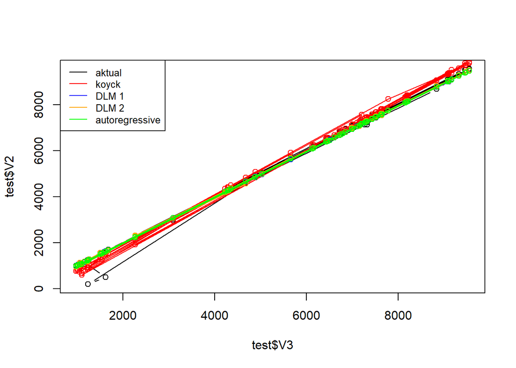

```r
par(mfrow=c(1,1))
plot(test$V3, test$V2, type="b", col="black")
points(test$V3, fore.koyck$forecasts,col="red")
lines(test$V3, fore.koyck$forecasts,col="red")
points(test$V3, fore.dlm$forecasts,col="blue")
lines(test$V3, fore.dlm$forecasts,col="blue")
points(test$V3, fore.dlm2$forecasts,col="orange")
lines(test$V3, fore.dlm2$forecasts,col="orange")
points(test$V3, fore.ardl$forecasts,col="green")
lines(test$V3, fore.ardl$forecasts,col="green")
legend("topleft",c("aktual", "koyck","DLM 1","DLM 2", "autoregressive"), lty=1, col=c("black","red","blue","orange","green"), cex=0.8)
```

```r
dev.copy(png, "Perbandingan Setiap Model dengan Data Aktual")
```

```r
dev.off()
```

Berdasarkan plot tersebut, terlihat bahwa setiap plot cenderung mendekati data aktualnya , sehingga dapat disimpulkan semua model dapat digunakan dengan baik.